# CUNEF

# `Machine Learning`

# `02_Problem_Frauds: Análisis Dataset Frauds`

## Authors:

### Jorge Plaza Yuste

### Álvaro Gómez Pérez

## Contents:

1. Libraries, functions and configuration
2. Data loading and display
3. EDA \ 3.1 Understanding the data \ 3.2 Data types \ 3.3 Duplicate values analysis \ 3.4 Descriptive analysis \ 3.5 Target distribution \ 3.6 Null elements analysis \ 3.7 Outliers Analysis \ 3.8 Correlations Analysis \ 3.9 Plotting variables versus target
4. Modeling objectives
5. Variable Selection and Preprocessing \ 5.1 Dataset split \ 5.2 Individual Pipelines \ 5.3 Preprocessor \ 5.4 Oversampling
6. Model comparison \ 6.1 Modelo dummy \ 6.2 Random Forest \ 6.3 SVC \ 6.4 XGBOOST \ 6.5 Regresión logística (LASSO)) \ 6.6 LIGHT GBM \ 6.7 GLM - SGD
7. Tunning XGBoost
8. SHAP
9. Partial Dependence Plots 10.Conclusions

## 1. Libraries, functions and configuration

```python
# Libraries:
import numpy as np
import pandas as pd
import numpy as np
import seaborn as sns
from matplotlib import pyplot as plt
import plotly.express as px
import scipy.stats as stats
from scipy.stats import chi2_contingency
import lightgbm as lgb
from sklearn.pipeline import Pipeline
from sklearn.preprocessing import MinMaxScaler
from sklearn.preprocessing import OneHotEncoder
from sklearn.compose import make_column_transformer
from sklearn.dummy import DummyClassifier
from sklearn.ensemble import RandomForestClassifier
from sklearn.model_selection import train_test_split
from imblearn.over_sampling import SMOTE
from collections import Counter
from sklearn.linear_model import LogisticRegression
from sklearn.metrics import accuracy_score
from sklearn.metrics import precision_score
from sklearn.metrics import recall_score
from sklearn.metrics import fbeta_score
from sklearn.metrics import classification_report
from sklearn.metrics import roc_curve
from sklearn.metrics import confusion_matrix
from mlxtend.plotting import plot_confusion_matrix
from scikitplot.metrics import plot_cumulative_gain
from scikitplot.metrics import plot_lift_curve
from sklearn.metrics import roc_auc_score
from sklearn.metrics import precision_recall_curve
from sklearn.model_selection import RandomizedSearchCV
from xgboost import XGBClassifier
from sklearn.calibration import CalibratedClassifierCV
from sklearn.linear_model import SGDClassifier
from joblib import Parallel, delayed
from sklearn.inspection import plot_partial_dependence
import joblib
import random
import warnings
```

```python
#Functions and classes:
def get_deviation_of_mean_perc(df, list_var_continuous, target, multiplier):
    """
    Devuelve el porcentaje de valores que exceden del intervalo de confianza
    :type series:
    :param multiplier:
    :return:
    """
    pd_final = pd.DataFrame()

    for i in list_var_continuous:

        series_mean = df[i].mean()
        series_std = df[i].std()
        std_amp = multiplier * series_std
        left = series_mean - std_amp
        right = series_mean + std_amp
        size_s = df[i].size

        perc_goods = df[i][(df[i] >= left) & (df[i] <= right)].size/size_s
        perc_excess = df[i][(df[i] < left) | (df[i] > right)].size/size_s

        if perc_excess>0:
            pd_concat_percent = pd.DataFrame(df[target][(df[i] < left) | (df[i] > right)]\
                                            .value_counts(normalize=True).reset_index()).T
            pd_concat_percent.columns = [pd_concat_percent.iloc[0,0],
                                         pd_concat_percent.iloc[0,1]]
            pd_concat_percent = pd_concat_percent.drop('index',axis=0)
            pd_concat_percent['variable'] = i
            pd_concat_percent['sum_outlier_values'] = df[i][(df[i] < left) | (df[i] > right)].size
            pd_concat_percent['porcentaje_sum_null_values'] = perc_excess
            pd_final = pd.concat([pd_final, pd_concat_percent], axis=0).reset_index(drop=True)

    if pd_final.empty:
        print('No existen variables con valores nulos')

    return pd_final

def cramers_v(var1,var2):
    """
    calculate Cramers V statistic for categorial-categorial association.
    uses correction from Bergsma and Wicher,
    Journal of the Korean Statistical Society 42 (2013): 323-328

    confusion_matrix: tabla creada con pd.crosstab()

    """
    crosstab =np.array(pd.crosstab(var1,var2, rownames=None, colnames=None))
    chi2 = stats.chi2_contingency(crosstab)[0]
    n = crosstab.sum()
    phi2 = chi2 / n
    r, k = crosstab.shape
    phi2corr = max(0, phi2 - ((k-1)*(r-1))/(n-1))
    rcorr = r - ((r-1)**2)/(n-1)
    kcorr = k - ((k-1)**2)/(n-1)
    return np.sqrt(phi2corr / min((kcorr-1), (rcorr-1)))

def plot_feature(df, col_name, isContinuous, target):
    """
    Visualize a variable with and without faceting on the loan status.
    - df dataframe
    - col_name is the variable name in the dataframe
    - full_name is the full variable name
    - continuous is True if the variable is continuous, False otherwise
    """
    f, (ax1, ax2) = plt.subplots(nrows=2, ncols=1, figsize=(15,10), dpi=90)

    count_null = df[col_name].isnull().sum()
    if isContinuous:

        sns.histplot(df.loc[df[col_name].notnull(), col_name], kde=False, ax=ax1)
    else:
        sns.countplot(df[col_name], color='#5975A4', saturation=1, ax=ax1)
    ax1.set_xlabel(col_name)
    ax1.set_ylabel('Count')
    ax1.set_title(col_name+ ' Numero de nulos: '+str(count_null))
    plt.xticks(rotation = 90)


    if isContinuous:
        sns.boxplot(x=col_name, y=target, data=df, ax=ax2)
        ax2.set_ylabel('')
        ax2.set_title(col_name + ' by '+target)
    else:
        data = df.groupby(col_name)[target].value_counts(normalize=True).to_frame('proportion').reset_index()
        data.columns = [i, target, 'proportion']
        #sns.barplot(x = col_name, y = 'proportion', hue= target, data = data, saturation=1, ax=ax2)
        sns.barplot(x = col_name, y = 'proportion', hue= target, data = data, saturation=1, ax=ax2)
        ax2.set_ylabel(target+' fraction')
        ax2.set_title(target)
        plt.xticks(rotation = 90)
    ax2.set_xlabel(col_name)

    plt.tight_layout()


def plot_fraud(df, col_name):
    """
    Visualize a variable with and without faceting on the loan status.
    - df dataframe
    - col_name is the variable name in the dataframe
    """
    f, (ax1) = plt.subplots(nrows=1, ncols=1, figsize=(15,5), dpi=90)

    count_null = df[col_name].isnull().sum()

    sns.countplot(df[col_name], color='#5975A4', saturation=1, ax=ax1)
    ax1.set_xlabel(col_name)
    ax1.set_ylabel('Count')
    ax1.set_title(col_name+ ' Numero de nulos: '+str(count_null))
    plt.xticks(rotation = 90)

    plt.tight_layout()

class select_variables():
    """
    Two modifications to the dataset
    - Remove race NameDest and NameOrig columns
    - Create a binary column called nameDest
    """
    def fit(self, X, y=None):
        return self

    def transform(self, X):
        X['nameDest_binary'] = X['nameDest'].str[:1]
        X = X.drop(['nameDest','nameOrig','race'], axis=1)
        return X

class impute_variables():
    """
    Two modifications to the dataset
    - Imputation of null values in gender columns according to category proportions in the data
    - Imputation of null values in device and zone columns with a new category

    """
    def fit(self, X, y=None):
        return self

    def transform(self, X):

        # Transform gender
        prop = X.gender.value_counts(normalize=True, dropna=True)*100
        total_nans = sum(X.gender.isna())
        X.gender[X.gender.isna()] = random.choices(['woman', 'unknow', 'man'],
                                                        weights=[prop.iloc[0], prop.iloc[1], prop.iloc[2]], k=total_nans)
        # Transform device and zone:
        X.device = data.device.fillna('unknown')
        X.zone = data.zone.fillna('unknown')

        return X


class comma_to_dot():
    """
    One modification to the dataset
    -Converting connection time type into a float

    """
    def fit(self, X, y=None):
        return self

    def transform(self, X):
        X.connection_time = X.connection_time.str.replace(',', '.').astype(float)
        return X

class scaler_pipeline():
    """
    One modification to the dataset
    -Scale the numeric data with the Min Max method

    """
    def fit(self, X, y=None):
        return self

    def transform(self, X):
        scaler = MinMaxScaler()
        numeric_features = X.select_dtypes(include=['int64', 'float64']).columns
        # transform data
        X[numeric_features] = scaler.fit_transform(X[numeric_features])
        return X

class encoder_pipeline():
    """
    One modification to the dataset
    -Encode the categorical data with the one hot encoder method

    """
    def fit(self, X, y=None):
        return self

    def transform(self, X):
        #Categrical features to pass down the categorical pipeline
        categorical_features = X.select_dtypes(include=['object']).columns
        transformer = make_column_transformer(
            (OneHotEncoder(handle_unknown='ignore'), categorical_features),
            remainder='passthrough')
        X = transformer.fit_transform(X)
        X = pd.DataFrame(X, columns=transformer.get_feature_names())
        return X

def show_metrics(y_true, y_pred, y_pred_proba, modelo):
    """
    Obtain the metrics for a specific model
    -accuracy
    -precision
    -recall
    -f2
    -auc
    """
    accuracy = round(accuracy_score(y_true, y_pred),4)
    precision = round(precision_score(y_true, y_pred),4)
    recall = round(recall_score(y_true, y_pred),4)
    f2 = round(fbeta_score(y_true, y_pred, beta=2),4)
    auc = roc_auc_score(y_true, y_pred_proba[:,1])


    print(modelo, 'metrics: \n'\
         'Accuracy: ',str(accuracy),'\n'\
         'Precision: ',str(precision),'\n'\
         'Recall: ',str(recall),'\n'\
         'F2: ',str(f2),'\n'\
         'AUC: ',str(auc))

def confusion_matrix_plot(ytest, ypred):
    """
    Obtain the confusion matrix of the predictions for each model
    -Confusion matrix without normalization
    -Confusion matrix with normalization
    """
    cm = confusion_matrix(ytest, ypred)
    cm_norm = confusion_matrix(ytest, ypred, normalize='true')
    f, (ax1, ax2) = plt.subplots(nrows=1, ncols=2, figsize=(12,3), dpi=90)
    sns.heatmap(cm, annot=True, fmt=".0f", linewidths=.5,
                square = True, cmap = plt.cm.Blues,ax=ax1)
    ax1.set_title("Confusion matrix, without normalization")
    ax1.set_xlabel('Predicted values')
    ax1.set_ylabel('Real values')
    sns.heatmap(cm_norm, annot=True, fmt=".2f", linewidths=.5,
                square = True, cmap = plt.cm.Blues,ax=ax2)
    ax2.set_title("Normalized confusion matrix")
    ax2.set_xlabel('Predicted values')
    ax2.set_ylabel('Real values')
    plt.tight_layout()

def curves(ytest, prob_predictions):
    """
    -get the Roc Curve
    -get the cumulative_gain_curve
    -get the lift curve
    """
    f, (ax1, ax2, ax3) = plt.subplots(nrows=1, ncols=3, figsize=(12,3), dpi=90)
    # ROC curve:
    # keep probabilities for the positive outcome only
    yhat = prob_predictions[:, 1]
    # calculate roc curves
    fpr, tpr, thresholds = roc_curve(ytest, yhat)
    # plot the roc curve for the model
    ax1.plot([0,1], [0,1], linestyle='--', label='No Skill')
    ax1.plot(fpr, tpr, marker='.', label='Random Forest')
    ax1.set_title("ROC Curve")
    ax1.set_xlabel('False Positive Rate')
    ax1.set_ylabel('True Positive Rate')
    ax1.legend()

    # Gain curve:
    plot_cumulative_gain(ytest, prob_predictions, ax=ax2)

    # Lift Curve:
    plot_lift_curve(ytest, prob_predictions, ax=ax3)

def plot_precision_recall_curve(ytest, prob_predictions, modelo):
    """
    -get precision - recall curve
    """
    # keep probabilities for the positive outcome only
    yhat = prob_predictions[:, 1]
    # calculate pr-curve
    precision, recall, thresholds = precision_recall_curve(ytest, yhat)
    # convert to f2 score
    f2_score = (5 * precision * recall) / (precision * 4 + recall)
    # locate the index of the largest f score
    ix = np.nanargmax(f2_score)
    print('Best Threshold=%f, F2-Score=%.3f' % (thresholds[ix], f2_score[ix]))
    # plot the precision-recall curve for the model
    plt.plot(recall, precision, marker='.', label=modelo)
    plt.scatter(recall[ix], precision[ix], s=100, marker='o', color='black', label='Best')
    # axis labels
    plt.xlabel('Recall')
    plt.ylabel('Precision')
    plt.legend()
    # show the plot
    plt.show()
```

```python
# Notebook Configuration
pd.set_option('display.max_columns', 500)
pd.set_option('display.max_rows', 500)
pd.set_option("max_colwidth", 100)
```

## 2. Data loading and display

```python
# Setting the files into variables
file_data = '../data/Copia de Original_dataset_payments_fraud.csv'
file_dict = '../data/Book1.xlsx'

# Loading the data and dictionary
data = pd.read_csv(file_data, sep=';')
dictionary = pd.read_excel(file_dict)
```

```python
# dictionary display
dictionary
```

|  | Variable | Descripcion | Tipo |
| --- | --- | --- | --- |
| 0 | step | Unidad de tiempo (horas) a la que se registró la transacción | Integer |
| 1 | type | Tipo de transacción | Categorical |
| 2 | amount | Importe de la transacción | Float |
| 3 | gender | Género del usuario que realiza la transacción | Categorical |
| 4 | device | Dispositivo desde el que se realizó la transacción | Categorical |
| 5 | connection_time | Segundos que trada en llegar los datos de la transacción | Float |
| 6 | nameOrig | Id del usuario que realiza la transacción | String |
| 7 | race | Raza o etnia del usuario que realiza la transacción | Categorical |
| 8 | oldbalanceOrig | Saldo del usuario antes de realizar la transacción | Float |
| 9 | age | Edad estimada del usuario que realiza la transacción | Integer |
| 10 | newbalanceOrig | Saldo del usuario después de realizar la transacción | Float |
| 11 | zone | Lugar desde el que se realiza la transacción | Categorical |
| 12 | user_number | Usuarios conectados en la web a la hora de hacer la transacción | Integer |
| 13 | nameDest | Receptor de la transacción | String |
| 14 | user_connections | Conexiones del usuario en ese mismo día | Integer |
| 15 | security_alert | Si existía alterta de seguridad por las autoridades ese día | Categorical |
| 16 | oldbalanceDest | Balance inicial del destinatario | Float |
| 17 | newbalanceDest | Balance final del destinatario | Float |
| 18 | isFraud | Indica si existe fraude o no | Categorical |

```python
# data display:
data
```

|  | step | type | amount | gender | device | connection_time | nameOrig | race | oldbalanceOrg | age | newbalanceOrig | zone | user_number | nameDest | user_connections | security_alert | oldbalanceDest | newbalanceDest | isFraud |
| --- | --- | --- | --- | --- | --- | --- | --- | --- | --- | --- | --- | --- | --- | --- | --- | --- | --- | --- | --- |
| 0 | 1 | PAYMENT | 9839.64 | man | mac | 0,140039412 | C1231006815 | black | 170136.00 | 85 | 160296.36 | capital | 138 | M1979787155 | 5 | 1 | 0.00 | 0.00 | 0 |
| 1 | 1 | PAYMENT | 1864.28 | woman | mac | 0,496889534 | C1666544295 | asian | 21249.00 | 57 | 19384.72 | country | 909 | M2044282225 | 1 | 0 | 0.00 | 0.00 | 0 |
| 2 | 1 | TRANSFER | 181.00 | man | pc | 0,781150327 | C1305486145 | asian | 181.00 | 66 | 0.00 | capital | 2569 | C553264065 | 10 | 0 | 0.00 | 0.00 | 1 |
| 3 | 1 | CASH_OUT | 181.00 | man | mac | 0,565068378 | C840083671 | black | 181.00 | 31 | 0.00 | country | 1787 | C38997010 | 3 | 0 | 21182.00 | 0.00 | 1 |
| 4 | 1 | PAYMENT | 11668.14 | unknow | mac | 0,517114493 | C2048537720 | black | 41554.00 | 90 | 29885.86 | country | 3997 | M1230701703 | 8 | 0 | 0.00 | 0.00 | 0 |
| ... | ... | ... | ... | ... | ... | ... | ... | ... | ... | ... | ... | ... | ... | ... | ... | ... | ... | ... | ... |
| 1048570 | 95 | CASH_OUT | 132557.35 | woman | mac | 0,420243195 | C1179511630 | black | 479803.00 | 39 | 347245.65 | NaN | 3179 | C435674507 | 9 | 0 | 484329.37 | 616886.72 | 0 |
| 1048571 | 95 | PAYMENT | 9917.36 | woman | mac | 0,37616924 | C1956161225 | black | 90545.00 | 36 | 80627.64 | africa | 2558 | M668364942 | 9 | 0 | 0.00 | 0.00 | 0 |
| 1048572 | 95 | PAYMENT | 14140.05 | unknow | pc | 0,837108874 | C2037964975 | black | 20545.00 | 31 | 6404.95 | africa | 1553 | M1355182933 | 2 | 0 | 0.00 | 0.00 | 0 |
| 1048573 | 95 | PAYMENT | 10020.05 | man | mac | 0,480931208 | C1633237354 | black | 90605.00 | 94 | 80584.95 | country | 642 | M1964992463 | 8 | 0 | 0.00 | 0.00 | 0 |
| 1048574 | 95 | PAYMENT | 11450.03 | man | pc | 0,868197534 | C1264356443 | black | 80584.95 | 84 | 69134.92 | country | 2081 | M677577406 | 4 | 0 | 0.00 | 0.00 | 0 |

1048575 rows × 19 columns

### Dataset dimensions

```python
data.shape
```

```
(1048575, 19)
```

## 3. EDA

We create a copy of the dataset so as not to contaminate the data during the descriptive analysis.

```python
data_eda = data.copy()
```

The `nameOrig` and `nameDest` columns are identifiers so they should not provide relevant information. However, the `nameDest` variable presents destination identifiers starting with two different letters (C or M). A binary variable has not been used for the `nameOrig` variable since all its Ids start with "C". We will therefore add a new categorical column indicating this difference in the Ids to check if it provides relevant information. If this is true, this process will be incorporated into the corresponding Pipeline.

### 3.1 Understanding the data

```python
# Extracting the first letter of the column to create a new one:
data_eda['nameDest_binary'] = data_eda['nameDest'].str[:1]
data_eda.head()
```

|  | step | type | amount | gender | device | connection_time | nameOrig | race | oldbalanceOrg | age | newbalanceOrig | zone | user_number | nameDest | user_connections | security_alert | oldbalanceDest | newbalanceDest | isFraud | nameDest_binary |
| --- | --- | --- | --- | --- | --- | --- | --- | --- | --- | --- | --- | --- | --- | --- | --- | --- | --- | --- | --- | --- |
| 0 | 1 | PAYMENT | 9839.64 | man | mac | 0,140039412 | C1231006815 | black | 170136.0 | 85 | 160296.36 | capital | 138 | M1979787155 | 5 | 1 | 0.0 | 0.0 | 0 | M |
| 1 | 1 | PAYMENT | 1864.28 | woman | mac | 0,496889534 | C1666544295 | asian | 21249.0 | 57 | 19384.72 | country | 909 | M2044282225 | 1 | 0 | 0.0 | 0.0 | 0 | M |
| 2 | 1 | TRANSFER | 181.00 | man | pc | 0,781150327 | C1305486145 | asian | 181.0 | 66 | 0.00 | capital | 2569 | C553264065 | 10 | 0 | 0.0 | 0.0 | 1 | C |
| 3 | 1 | CASH_OUT | 181.00 | man | mac | 0,565068378 | C840083671 | black | 181.0 | 31 | 0.00 | country | 1787 | C38997010 | 3 | 0 | 21182.0 | 0.0 | 1 | C |
| 4 | 1 | PAYMENT | 11668.14 | unknow | mac | 0,517114493 | C2048537720 | black | 41554.0 | 90 | 29885.86 | country | 3997 | M1230701703 | 8 | 0 | 0.0 | 0.0 | 0 | M |

### 3.2 Data types

```python
#converting the variable typeinto a float
data_eda['connection_time'] = data_eda['connection_time'].str.replace(',', '.').astype(float)

# Storing the names of the categorical and numeric columns.
data_category = ['type','gender','device','nameOrig','race',
                  'zone', 'nameDest','nameDest_binary','security_alert','isFraud']
data_numeric = ['step','amount','connection_time','oldbalanceOrg','age','newbalanceOrig',
                'user_number','user_connections','oldbalanceDest','newbalanceDest']

# Transforming object type to category
data_eda[data_category]= data_eda[data_category].apply(lambda x: x.astype('category'))
data_eda.dtypes
```

```
step                   int64
type                category
amount               float64
gender              category
device              category
connection_time      float64
nameOrig            category
race                category
oldbalanceOrg        float64
age                    int64
newbalanceOrig       float64
zone                category
user_number            int64
nameDest            category
user_connections       int64
security_alert      category
oldbalanceDest       float64
newbalanceDest       float64
isFraud             category
nameDest_binary     category
dtype: object
```

### 3.3 Duplicate values analysis

```python
print(data_eda.shape, data_eda.drop_duplicates().shape, '->', str(data_eda.shape[0]-data_eda.drop_duplicates().shape[0]), 'duplicados.')
```

```
(1048575, 20) (1048575, 20) -> 0 duplicados.
```

### 3.4 Descriptive analysis

```python
# numeric data:
data_eda[data_numeric].describe()
```

|  | step | amount | connection_time | oldbalanceOrg | age | newbalanceOrig | user_number | user_connections | oldbalanceDest | newbalanceDest |
| --- | --- | --- | --- | --- | --- | --- | --- | --- | --- | --- |
| count | 1.048575e+06 | 1.048575e+06 | 1.048575e+06 | 1.048575e+06 | 1.048575e+06 | 1.048575e+06 | 1.048575e+06 | 1.048575e+06 | 1.048575e+06 | 1.048575e+06 |
| mean | 2.696617e+01 | 1.586670e+05 | 5.000671e-01 | 8.740055e+05 | 5.245674e+01 | 8.938049e+05 | 2.530440e+03 | 5.503561e+00 | 9.781600e+05 | 1.114193e+06 |
| std | 1.562325e+01 | 2.649409e+05 | 2.885239e-01 | 2.971725e+06 | 2.772639e+01 | 3.008246e+06 | 1.426418e+03 | 2.872241e+00 | 2.296779e+06 | 2.416554e+06 |
| min | 1.000000e+00 | 1.000000e-01 | 2.618800e-08 | 0.000000e+00 | 5.000000e+00 | 0.000000e+00 | 5.900000e+01 | 1.000000e+00 | 0.000000e+00 | 0.000000e+00 |
| 25% | 1.500000e+01 | 1.214907e+04 | 2.500884e-01 | 0.000000e+00 | 2.800000e+01 | 0.000000e+00 | 1.295000e+03 | 3.000000e+00 | 0.000000e+00 | 0.000000e+00 |
| 50% | 2.000000e+01 | 7.634333e+04 | 5.003599e-01 | 1.600200e+04 | 5.200000e+01 | 0.000000e+00 | 2.532000e+03 | 6.000000e+00 | 1.263772e+05 | 2.182604e+05 |
| 75% | 3.900000e+01 | 2.137619e+05 | 7.496531e-01 | 1.366420e+05 | 7.600000e+01 | 1.746000e+05 | 3.765000e+03 | 8.000000e+00 | 9.159235e+05 | 1.149808e+06 |
| max | 9.500000e+01 | 1.000000e+07 | 9.999991e-01 | 3.893942e+07 | 1.000000e+02 | 3.894623e+07 | 5.000000e+03 | 1.000000e+01 | 4.205466e+07 | 4.216916e+07 |

```python
# categorical data:
data_eda[data_category].describe()
```

|  | type | gender | device | nameOrig | race | zone | nameDest | nameDest_binary | security_alert | isFraud |
| --- | --- | --- | --- | --- | --- | --- | --- | --- | --- | --- |
| count | 1048575 | 943457 | 943995 | 1048575 | 943412 | 944161 | 1048575 | 1048575 | 1048575 | 1048575 |
| unique | 5 | 3 | 3 | 1048317 | 3 | 3 | 449635 | 2 | 2 | 2 |
| top | CASH_OUT | woman | mac | C664297940 | asian | country | C985934102 | C | 0 | 0 |
| freq | 373641 | 366906 | 367066 | 2 | 366338 | 368004 | 98 | 694702 | 943670 | 1047433 |

### 3.5 Target distribution

```python
# getting the percetage for the IsFraud column classes:
fraude_percentage = data_eda['isFraud']\
        .value_counts(normalize=True)\
        .mul(100).rename('Percentage').reset_index()
fraude_percentage_count = data_eda['isFraud'].value_counts().reset_index()
fraude_percentage_distribution = pd.merge(fraude_percentage, fraude_percentage_count, on=['index'], how='inner')
fraude_percentage_distribution[['Percentage','isFraud']]
```

|  | Percentage | isFraud |
| --- | --- | --- |
| 0 | 99.89109 | 1047433 |
| 1 | 0.10891 | 1142 |

```python
# plotting target distribution:
fig = px.pie(fraude_percentage_distribution, names="index", values='Percentage')
fig.show()
```

[interactive chart not shown]

We can see that the target is very unbalanced.

### 3.6 Null elements analysis

```python
#Evaluating the null elements in the dataset:
pd_null_columnas = pd.DataFrame(data_eda.isnull().sum().sort_values(ascending=False), columns=['nulos_columnas'])
pd_null_filas = pd.DataFrame(data_eda.isnull().sum(axis=1).sort_values(ascending=False), columns=['nulos_filas'])
#Getting the proportions:
pd_null_columnas['Proporcion_columnas'] = pd_null_columnas['nulos_columnas']/data_eda.shape[0]
pd_null_filas['Proporcion_filas']= pd_null_filas['nulos_filas']/data_eda.shape[1]
```

```python
# nulls (rows) display:
pd_null_filas
```

|  | nulos_filas | Proporcion_filas |
| --- | --- | --- |
| 89367 | 4 | 0.2 |
| 574234 | 4 | 0.2 |
| 201502 | 4 | 0.2 |
| 927846 | 4 | 0.2 |
| 556042 | 4 | 0.2 |
| ... | ... | ... |
| 422513 | 0 | 0.0 |
| 422514 | 0 | 0.0 |
| 422516 | 0 | 0.0 |
| 422518 | 0 | 0.0 |
| 1048574 | 0 | 0.0 |

1048575 rows × 2 columns

```python
# nulls (columns) display:
pd_null_columnas
```

|  | nulos_columnas | Proporcion_columnas |
| --- | --- | --- |
| race | 105163 | 0.100291 |
| gender | 105118 | 0.100248 |
| device | 104580 | 0.099735 |
| zone | 104414 | 0.099577 |
| step | 0 | 0.000000 |
| user_number | 0 | 0.000000 |
| isFraud | 0 | 0.000000 |
| newbalanceDest | 0 | 0.000000 |
| oldbalanceDest | 0 | 0.000000 |
| security_alert | 0 | 0.000000 |
| user_connections | 0 | 0.000000 |
| nameDest | 0 | 0.000000 |
| newbalanceOrig | 0 | 0.000000 |
| type | 0 | 0.000000 |
| age | 0 | 0.000000 |
| oldbalanceOrg | 0 | 0.000000 |
| nameOrig | 0 | 0.000000 |
| connection_time | 0 | 0.000000 |
| amount | 0 | 0.000000 |
| nameDest_binary | 0 | 0.000000 |

### 3.7 Outliers Analysis

```python
get_deviation_of_mean_perc(data_eda, data_numeric, target='isFraud', multiplier=3)
```

|  | 0.0 | 1.0 | variable | sum_outlier_values | porcentaje_sum_null_values |
| --- | --- | --- | --- | --- | --- |
| 0 | 0.986447 | 0.013553 | step | 18004 | 0.017170 |
| 1 | 0.981773 | 0.018227 | amount | 19422 | 0.018522 |
| 2 | 0.999311 | 0.000689 | oldbalanceOrg | 26140 | 0.024929 |
| 3 | 1.000000 | 0.000000 | newbalanceOrig | 26282 | 0.025064 |
| 4 | 0.999427 | 0.000573 | oldbalanceDest | 22685 | 0.021634 |
| 5 | 0.998513 | 0.001487 | newbalanceDest | 22862 | 0.021803 |

The outliers do not seem to influence the tarjet. We decided not to replace them in the first place. Subsequently, if there is a need to improve the model results, it would be possible to consider different methods and check if there is an improvement.

### 3.8 Correlations Analysis

#### Numeric Correlation

```python
# calculating pearson correlation:
corr = data_eda.corr(method = 'pearson')
```

```python
# converting the correlation matrix to triangular correlation matrix:
mask = np.zeros_like(corr, dtype='bool')
mask[np.triu_indices_from(mask)] = True
```

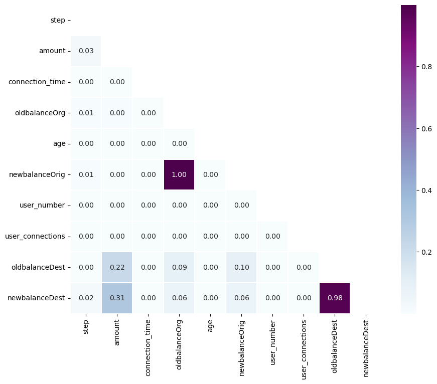

```python
# plotting the final matrix
plt.figure(figsize = (10, 8))
sns.heatmap(corr.abs(), mask=mask, cmap ='BuPu', annot=True, fmt='.2f', linewidths=0.01)
plt.show()
```

#### Categoric Association

The `nameOrig` and `nameDest` columns are identifiers, so they have too many unique values and it does not make sense to analyze their relationship with the rest of the categorical variables.

```python
# Removing Id's:
categorical_data = data_eda[data_category].drop(['nameOrig', 'nameDest'], axis=1)

# Creating an empty matrix:
cramer_matrix = np.zeros((len(categorical_data.columns),len(categorical_data.columns)))

# Filling the matrix with the Cramer's V association values:
for i in range(0,len(categorical_data.columns)):
    for j in range(0,len(categorical_data.columns)):
        cramer_matrix[i,j]=cramers_v(categorical_data.iloc[:,i],categorical_data.iloc[:,j])

# Converting the correlation matrix to a triangular one
mask = np.zeros_like(cramer_matrix, dtype='bool')
mask[np.triu_indices_from(mask)] = True
```

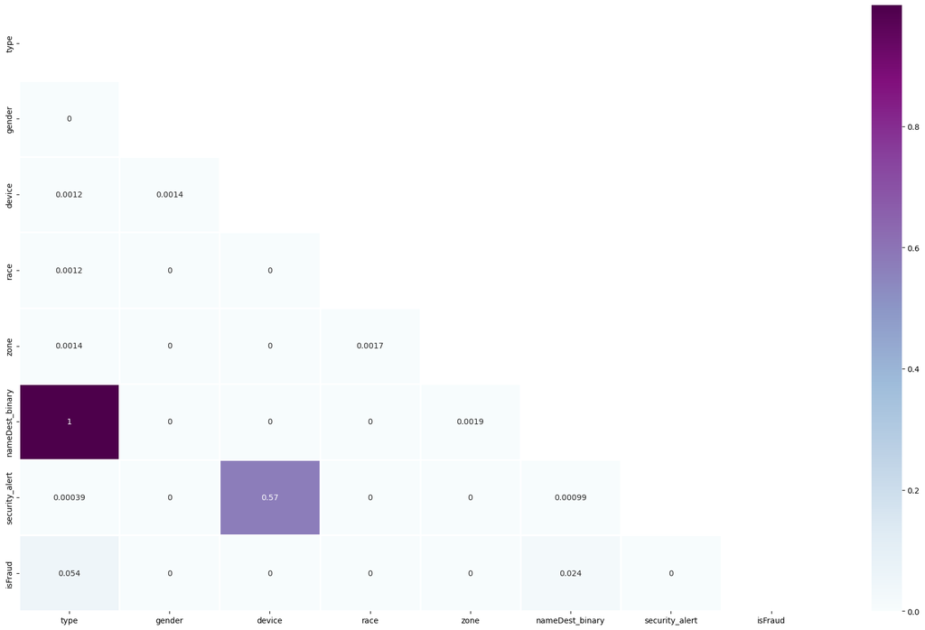

```python
# Plotting the final matrix:
fig, ax = plt.subplots(figsize=(23, 14))
ax.plot()
ax = sns.heatmap(cramer_matrix, mask=mask, annot=True, linewidths=0.9, cmap="BuPu",
                 xticklabels=categorical_data.columns, yticklabels=categorical_data.columns)
```

The association between the type of transaction and the type of destination identifier is maximal, so it is possible that the information generated with this binary variable is redundant. In addition, the device type has a high degree of association with whether or not there was a security alert on the day of the transaction.

### 3.9 Plotting variables versus target

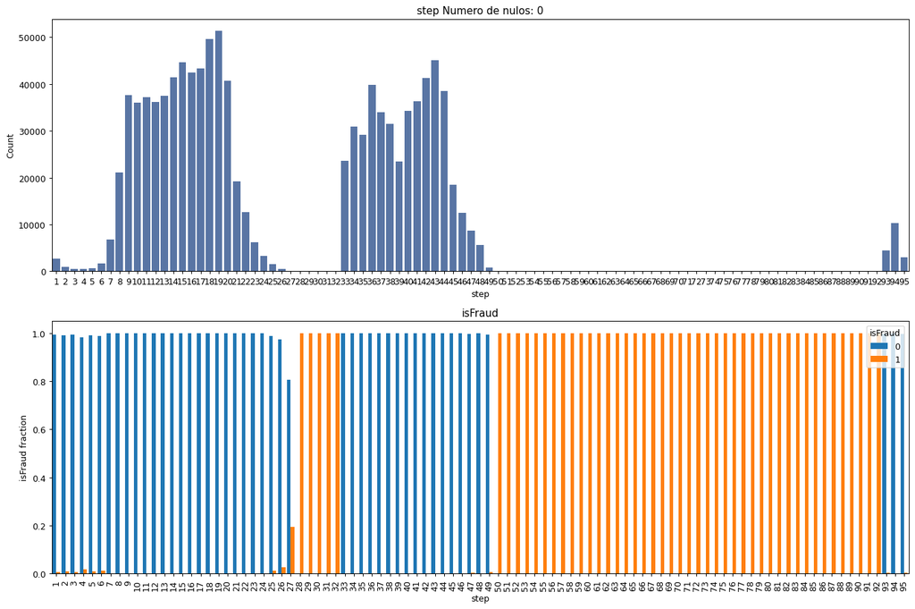

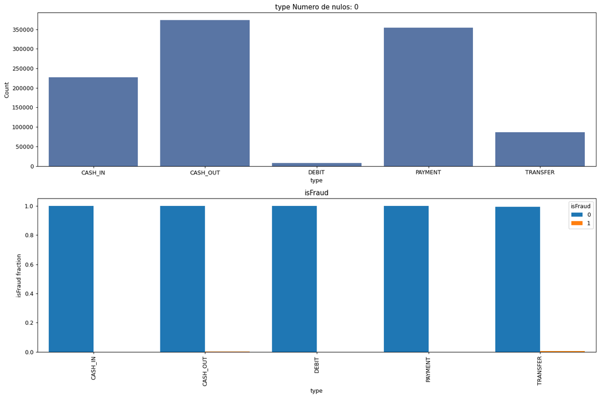

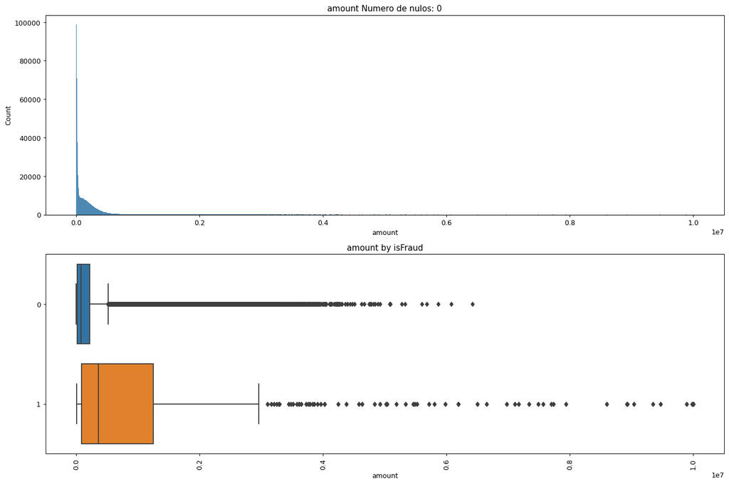

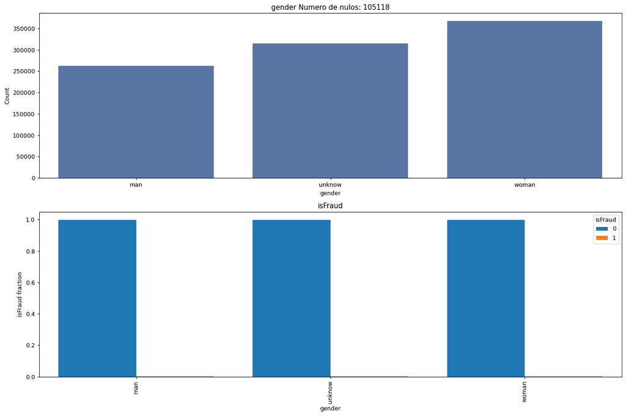

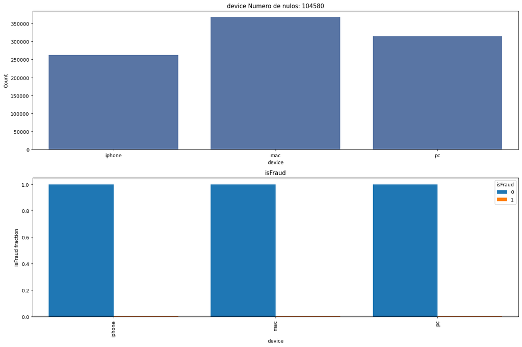

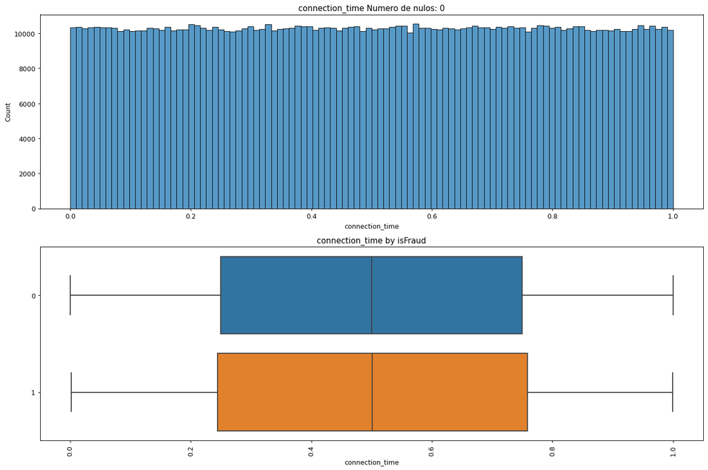

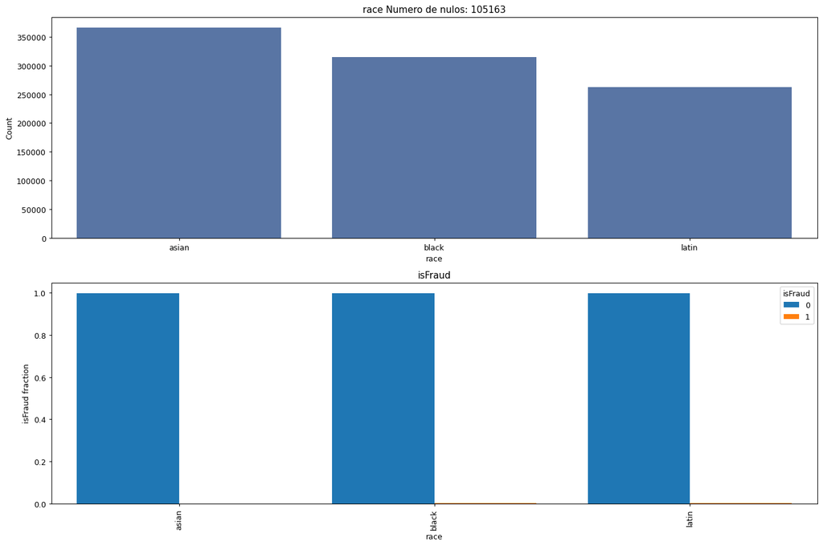

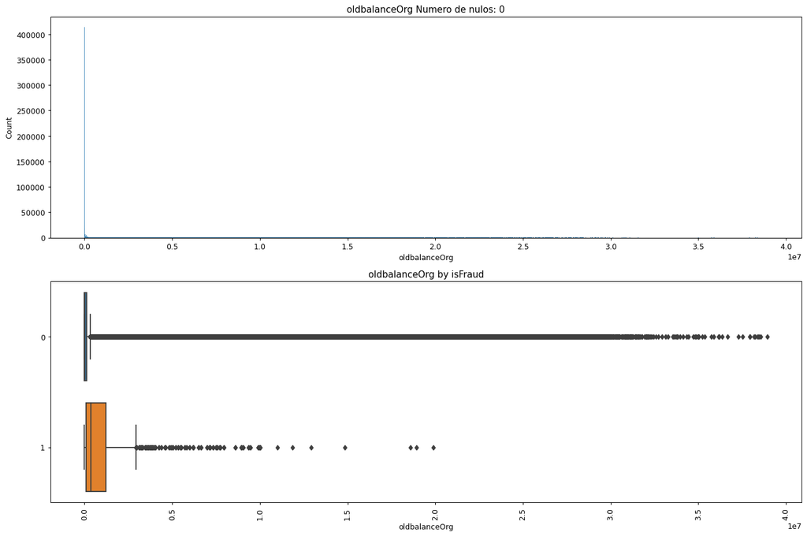

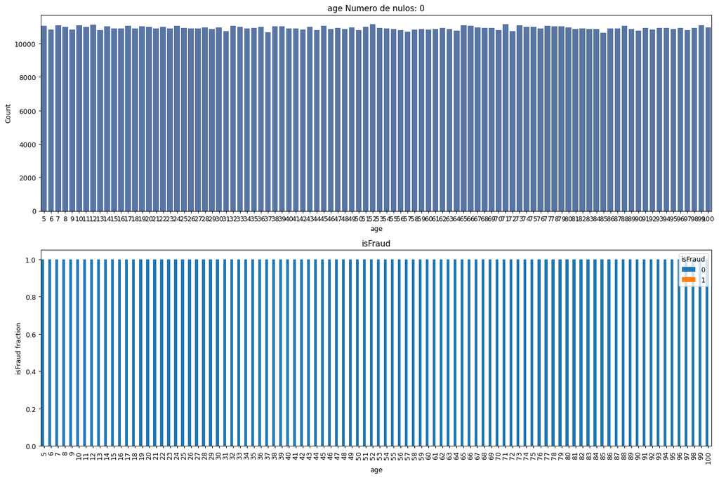

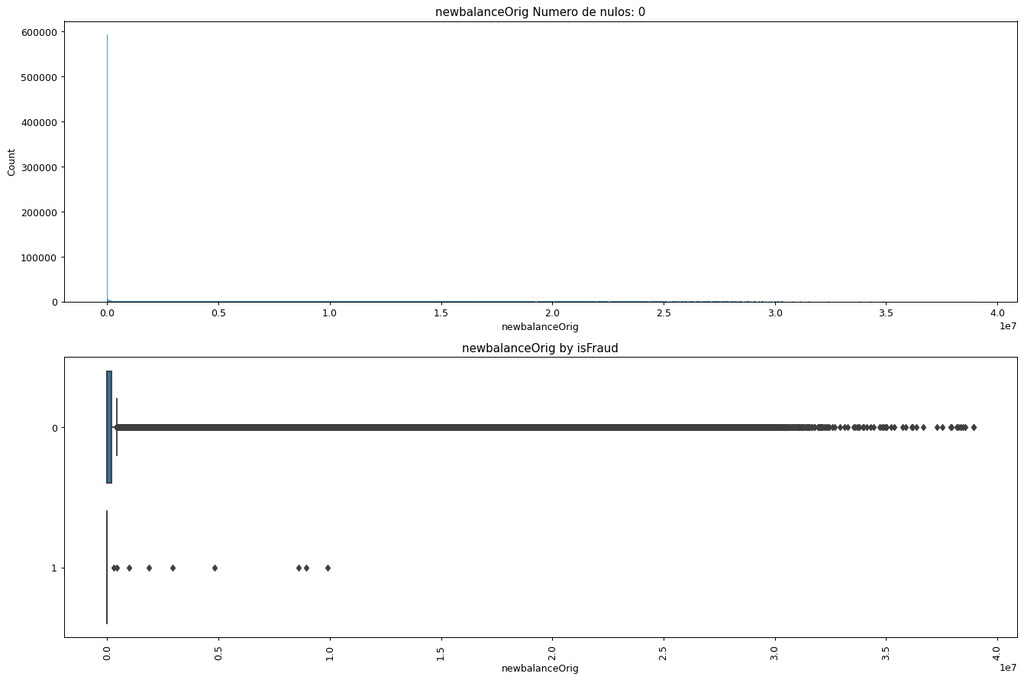

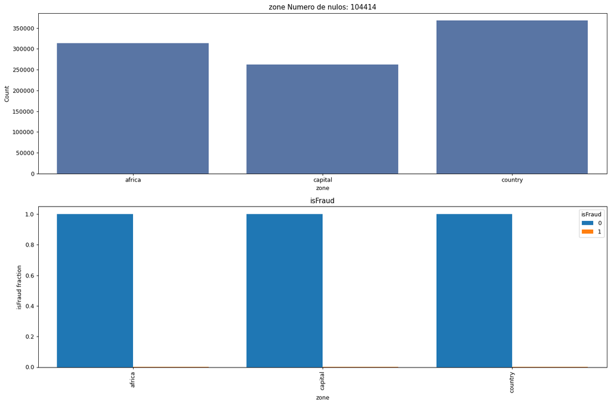

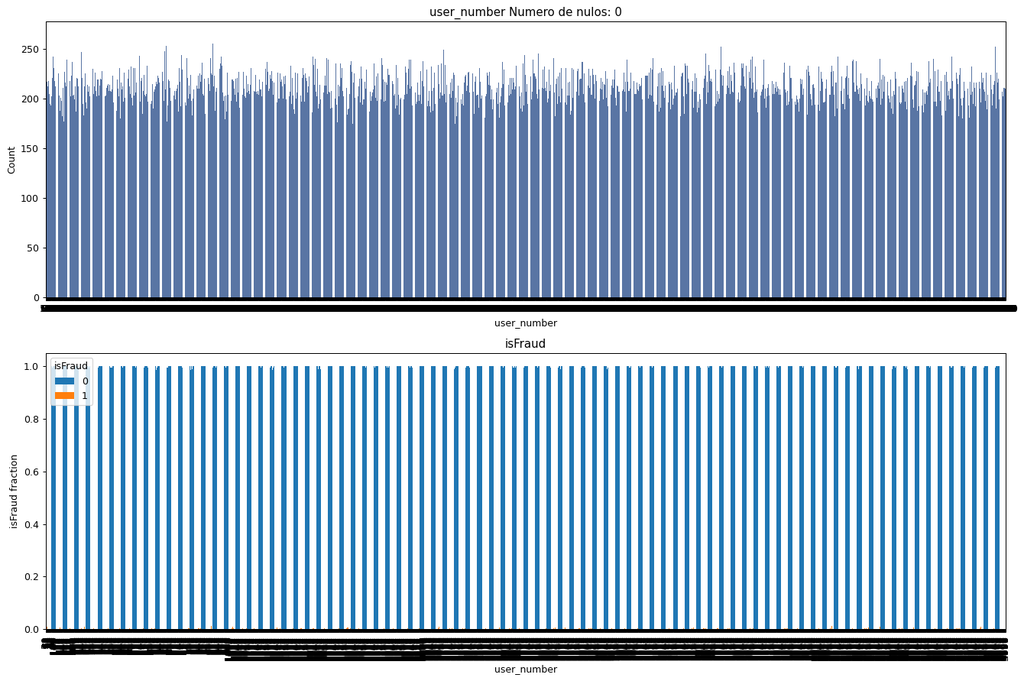

[5 more figures not shown]

```python
warnings.filterwarnings('ignore')
# Dropping Ids and evaluating which are continuous or categorical values in each case:
for i in list(data_eda.drop(['nameOrig','nameDest'],axis=1).columns):
    if (data_eda[i].dtype==float) & (i!='isFraud'):
        plot_feature(data_eda, col_name=i, isContinuous=True, target='isFraud')
    elif  i!='isFraud':
        plot_feature(data_eda, col_name=i, isContinuous=False, target='isFraud')
```

Looking at these graphs we realized at first, that we could get certain conclusions from the way in which fraudulent transactions were distributed in some of the categorical variables. To analyze this fact further, we decided to represent in the following graphs the distribution of frauds **(`isFraud=1`)** according to the categories of each of these variables.

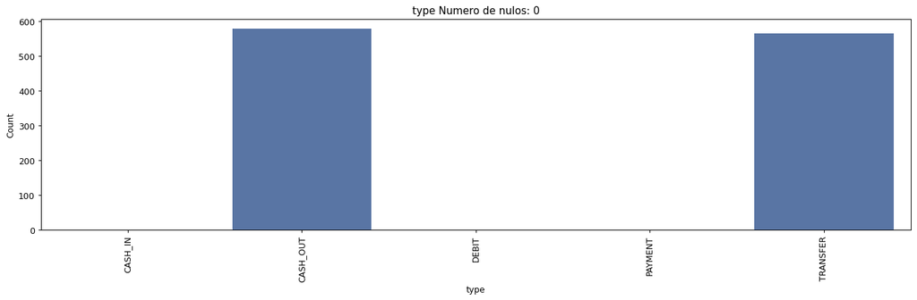

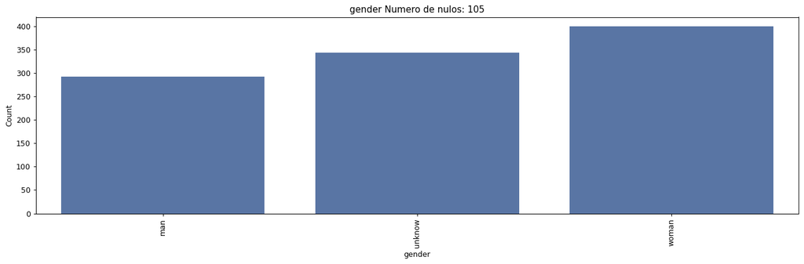

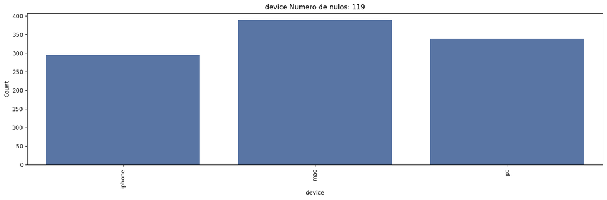

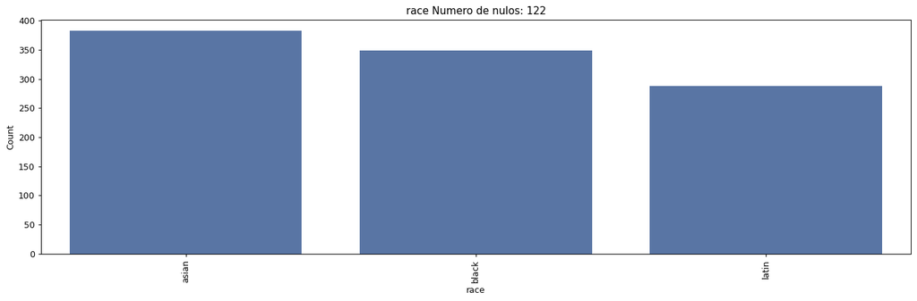

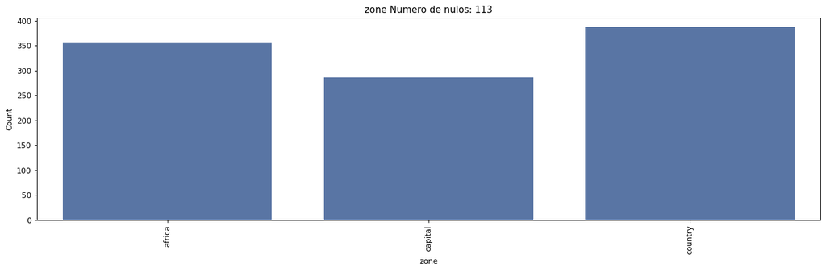

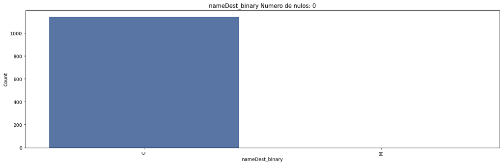

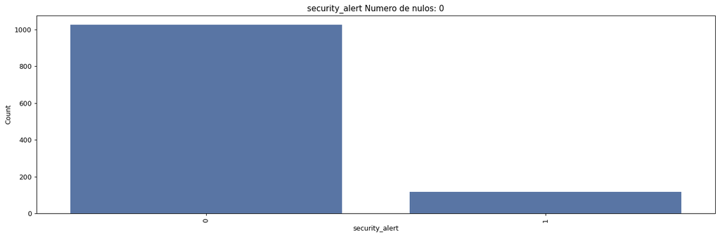

```python
warnings.filterwarnings('ignore')
# Plotting variables but only the rows with 'isFraud = 1'
for i in list(data_eda[data_category].drop(['nameOrig','nameDest','isFraud'],axis=1).columns):
    plot_fraud(data_eda[data_eda["isFraud"] == 1], col_name=i)
```

These graphs confirm our initial intuition. There are categorical variables in which only some categories account for almost all the frauds.

- In the case of the `type` variable, we observe that all fraudulent transactions were either a "transfer" or a "cash out".
- Since all the origin IDs (`nameOrig`) start with the letter "C", observing the fraud graph as a function of the nameDest_binary variable, we can see that practically all the fraudulent transactions were between IDs starting with the letter "C".
- Looking at the graph of the `security_alert` variable, we see that the vast majority of frauds occurred in those transactions in which there was no security alert that day, which is quite logical.

## 4. Modeling objectives

- Generate different machine learning models that will be able to output the probability of fraud.
- Compare the different models generated, to see which one offers better results.

## 5. Variable Selection and Preprocessing

### 5.1 Dataset split

```python
# Splitting predictor data and target data:
X = data.drop('isFraud', axis = 1)
Y = data.isFraud
# As we are with unbalanced data, stratify=Y
xtrain, xtest, ytrain, ytest = train_test_split(X, Y, test_size=0.25, stratify=Y, random_state=0)
```

### 5.2 Individual Pipelines

We have grouped all the preprocessing and variable selection in the same pipeline that will be shown later in order to have a more orderly code.

#### Variables selection

Since we do not have a large number of variables, we decided to keep them (except for the identifiers and the `race` column for reasons of discrimination or bias and data protection) so as not to lose predictive power. In addition, we consider that the `nameDest_binary` variable analyzed in the EDA can provide relevant information when generating the model.

```python
select_pipeline = Pipeline([
    ('select_variables', select_variables())
])
```

#### Variable Imputation

```python
impute_pipeline = Pipeline([
    ('impute_variables', impute_variables())
])
```

#### Connection time variable conversion

We have used another Pipeline to convert the `connection_time` variable to float.

```python
comma_to_dot_pipeline = Pipeline([
    ('comma_to_dot', comma_to_dot())
])
```

#### Scaling

To determine the method of scaling numerical data, we tested whether our data follow a normal distribution using the Shapiro-Wilk test.

```python
from scipy import stats

#Numerical features to pass down the scaling pipeline
numeric_features = xtrain.select_dtypes(include=['int64', 'float64']).columns
shapiro_test = stats.shapiro(xtrain[numeric_features])

print(shapiro_test)
if shapiro_test[1]<0.05:
    print('p-value:', shapiro_test[1], ', null hypothesis is rejected so we can claim that the Dataset does not follow a normal distribution')
else:
    print('p-value:', shapiro_test[1], ', we can not reject null hypothesis, so we suposse that the Dataset follows a normal distribution')
```

```
ShapiroResult(statistic=0.23664844036102295, pvalue=0.0)
p-value: 0.0 , null hypothesis is rejected so we can claim that the Dataset does not follow a normal distribution
```

```python
numeric_scaler = Pipeline([
    ('scaler', scaler_pipeline())
])
```

#### Encoding

We are going to use the `OneHotEncoder` to encode the non-binary categorical variables.

```python
#Defining the steps in the categorical pipeline
categorical_encoder = Pipeline([
    ('onehot', encoder_pipeline())
])
```

### 5.3 Preprocessor

```python
# Grouping all the individual pipelines:
preprocessor = Pipeline(steps=[
    ('select', select_pipeline),
    ('impute', impute_pipeline),
    ('comma2dot', comma_to_dot_pipeline),
    ('scaler', numeric_scaler),
    ('encoder', categorical_encoder)
    ])
```

```python
# Fitting the preprocessor:
preprocessor.fit(xtrain)
```

```
Pipeline(steps=[('select',
                 Pipeline(steps=[('select_variables',
                                  <__main__.select_variables object at 0x0000017A74959970>)])),
                ('impute',
                 Pipeline(steps=[('impute_variables',
                                  <__main__.impute_variables object at 0x0000017A7518F490>)])),
                ('comma2dot',
                 Pipeline(steps=[('comma_to_dot',
                                  <__main__.comma_to_dot object at 0x0000017A74A1C610>)])),
                ('scaler',
                 Pipeline(steps=[('scaler',
                                  <__main__.scaler_pipeline object at 0x0000017A75B06640>)])),
                ('encoder',
                 Pipeline(steps=[('onehot',
                                  <__main__.encoder_pipeline object at 0x0000017A75B062B0>)]))])
```

```python
# Getting de train data processed:
xtrain_processed = preprocessor.transform(xtrain)
```

```python
# Train data preprocessed display:
xtrain_processed
```

|  | onehotencoder__x0_CASH_IN | onehotencoder__x0_CASH_OUT | onehotencoder__x0_DEBIT | onehotencoder__x0_PAYMENT | onehotencoder__x0_TRANSFER | onehotencoder__x1_man | onehotencoder__x1_unknow | onehotencoder__x1_woman | onehotencoder__x2_iphone | onehotencoder__x2_mac | onehotencoder__x2_pc | onehotencoder__x2_unknown | onehotencoder__x3_africa | onehotencoder__x3_capital | onehotencoder__x3_country | onehotencoder__x3_unknown | onehotencoder__x4_C | onehotencoder__x4_M | step | amount | connection_time | oldbalanceOrg | age | newbalanceOrig | user_number | user_connections | security_alert | oldbalanceDest | newbalanceDest |
| --- | --- | --- | --- | --- | --- | --- | --- | --- | --- | --- | --- | --- | --- | --- | --- | --- | --- | --- | --- | --- | --- | --- | --- | --- | --- | --- | --- | --- | --- |
| 0 | 0.0 | 0.0 | 0.0 | 1.0 | 0.0 | 0.0 | 0.0 | 1.0 | 1.0 | 0.0 | 0.0 | 0.0 | 0.0 | 0.0 | 1.0 | 0.0 | 0.0 | 1.0 | 0.170213 | 0.000825 | 0.106776 | 0.000319 | 0.273684 | 0.000107 | 0.629630 | 0.222222 | 0.0 | 0.000000 | 0.000000 |
| 1 | 0.0 | 0.0 | 0.0 | 1.0 | 0.0 | 0.0 | 0.0 | 1.0 | 0.0 | 0.0 | 0.0 | 1.0 | 0.0 | 0.0 | 1.0 | 0.0 | 0.0 | 1.0 | 0.095745 | 0.000337 | 0.965321 | 0.000077 | 0.000000 | 0.000000 | 0.155637 | 0.111111 | 0.0 | 0.000000 | 0.000000 |
| 2 | 1.0 | 0.0 | 0.0 | 0.0 | 0.0 | 0.0 | 0.0 | 1.0 | 0.0 | 0.0 | 1.0 | 0.0 | 1.0 | 0.0 | 0.0 | 0.0 | 1.0 | 0.0 | 0.191489 | 0.012342 | 0.748009 | 0.112286 | 0.663158 | 0.115435 | 0.407812 | 0.111111 | 0.0 | 0.005401 | 0.002459 |
| 3 | 0.0 | 1.0 | 0.0 | 0.0 | 0.0 | 0.0 | 1.0 | 0.0 | 0.0 | 1.0 | 0.0 | 0.0 | 0.0 | 1.0 | 0.0 | 0.0 | 1.0 | 0.0 | 0.436170 | 0.011276 | 0.294075 | 0.000014 | 0.315789 | 0.000000 | 0.982999 | 0.777778 | 0.0 | 0.000000 | 0.002674 |
| 4 | 0.0 | 1.0 | 0.0 | 0.0 | 0.0 | 1.0 | 0.0 | 0.0 | 0.0 | 1.0 | 0.0 | 0.0 | 0.0 | 0.0 | 1.0 | 0.0 | 1.0 | 0.0 | 0.446809 | 0.004102 | 0.454834 | 0.001549 | 0.810526 | 0.000495 | 0.181745 | 1.000000 | 0.0 | 0.000000 | 0.000973 |
| ... | ... | ... | ... | ... | ... | ... | ... | ... | ... | ... | ... | ... | ... | ... | ... | ... | ... | ... | ... | ... | ... | ... | ... | ... | ... | ... | ... | ... | ... |
| 786426 | 0.0 | 0.0 | 0.0 | 1.0 | 0.0 | 0.0 | 0.0 | 1.0 | 1.0 | 0.0 | 0.0 | 0.0 | 0.0 | 1.0 | 0.0 | 0.0 | 0.0 | 1.0 | 0.000000 | 0.001050 | 0.084828 | 0.000069 | 0.126316 | 0.000000 | 0.082170 | 0.222222 | 1.0 | 0.000000 | 0.000000 |
| 786427 | 0.0 | 1.0 | 0.0 | 0.0 | 0.0 | 1.0 | 0.0 | 0.0 | 0.0 | 0.0 | 0.0 | 1.0 | 0.0 | 1.0 | 0.0 | 0.0 | 1.0 | 0.0 | 0.159574 | 0.004791 | 0.978753 | 0.000000 | 0.378947 | 0.000000 | 0.395264 | 0.888889 | 0.0 | 0.002244 | 0.003374 |
| 786428 | 0.0 | 0.0 | 0.0 | 1.0 | 0.0 | 1.0 | 0.0 | 0.0 | 0.0 | 0.0 | 1.0 | 0.0 | 0.0 | 0.0 | 1.0 | 0.0 | 0.0 | 1.0 | 0.148936 | 0.002855 | 0.799664 | 0.000000 | 0.378947 | 0.000000 | 0.657964 | 0.111111 | 0.0 | 0.000000 | 0.000000 |
| 786429 | 0.0 | 1.0 | 0.0 | 0.0 | 0.0 | 1.0 | 0.0 | 0.0 | 1.0 | 0.0 | 0.0 | 0.0 | 0.0 | 0.0 | 0.0 | 1.0 | 1.0 | 0.0 | 0.446809 | 0.018617 | 0.177884 | 0.000000 | 0.915789 | 0.000000 | 0.801457 | 0.777778 | 0.0 | 0.066139 | 0.070374 |
| 786430 | 0.0 | 0.0 | 0.0 | 1.0 | 0.0 | 0.0 | 1.0 | 0.0 | 0.0 | 0.0 | 1.0 | 0.0 | 0.0 | 0.0 | 1.0 | 0.0 | 0.0 | 1.0 | 0.393617 | 0.000080 | 0.839996 | 0.010695 | 0.747368 | 0.010672 | 0.738514 | 0.444444 | 0.0 | 0.000000 | 0.000000 |

786431 rows × 29 columns

### 5.4 Oversampling

Since we have such unbalanced data in terms of the target variable, we will use the smote method.

```python
# Oversampling the Frauds to 10% of the NoFrauds:
sm = SMOTE(sampling_strategy = 0.1, random_state=0)
xtrain_processed2, ytrain_processed = sm.fit_resample(xtrain_processed, ytrain)
print('Resampled dataset shape %s' % Counter(ytrain_processed))
```

```
Resampled dataset shape Counter({0: 785575, 1: 78557})
```

#### Test preprocessor

```python
# Getting de test data processed:
xtest_processed = preprocessor.transform(xtest)
```

## 6. Model comparison

We are going to evaluate several models and choose the best one based on their metrics.

In this problem it is important to look at false negatives (FN) and true positives (TP), i.e. to see how the model classifies frauds. A false negative is a high cost while a false positive is an affordable cost. Therefore, we have decided to emphasize the recall and f2 score metrics:

- $Recall = \frac{TP}{TP\hspace{1pt}+\hspace{1pt}FN}$
- $F_\beta Score = (1 + \beta^2)\frac{Precision \hspace{1mm}\times\hspace{1pt}Recall}{\beta^2 \hspace{1mm}\times\hspace{1pt}Precision \hspace{1pt}+\hspace{1pt} Recall}\hspace{6pt}{ / }\hspace{2pt} \beta = 2$

### 6.1 Modelo dummy

```python
# Creating de dummy model: imputing the mayority class.
clf_dummy=DummyClassifier(strategy="most_frequent")
clf_dummy.fit(xtrain_processed2, ytrain_processed)
```

```
DummyClassifier(strategy='most_frequent')
```

```python
# Predictions and metrics:
y_pred_dummy = clf_dummy.predict(xtest_processed)
y_pred_dummy_prob = clf_dummy.predict_proba(xtest_processed)
show_metrics(ytest, y_pred_dummy, y_pred_dummy_prob, 'Dummy')
print("\nClassification Report\n")
print(classification_report(ytest, y_pred_dummy))
```

```
Dummy metrics:
Accuracy:  0.9989
Precision:  0.0
Recall:  0.0
F2:  0.0
AUC:  0.5

Classification Report

              precision    recall  f1-score   support

           0       1.00      1.00      1.00    261858
           1       0.00      0.00      0.00       286

    accuracy                           1.00    262144
   macro avg       0.50      0.50      0.50    262144
weighted avg       1.00      1.00      1.00    262144
```

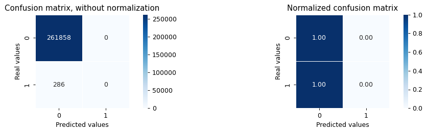

```python
# Confusion matrix display:
confusion_matrix_plot(ytest, y_pred_dummy)
```

The dummy model obtains very good accuracy, this is because most of the observations are not frauds and therefore are well classified, however, it does not classify well any of the observations that are frauds so it is not a good model.

### 6.2 Random Forest

```python
# Setting the model:
clf_random_forest=RandomForestClassifier()
```

#### Fitting the model

```python
# Fitting the model:
clf_random_forest.fit(xtrain_processed2, ytrain_processed)
```

```
RandomForestClassifier()
```

#### Predict

```python
# Calculating the probs for each class:
y_pred_random_forest_prob = clf_random_forest.predict_proba(xtest_processed)
```

```
Best Threshold=0.570000, F2-Score=0.842
```

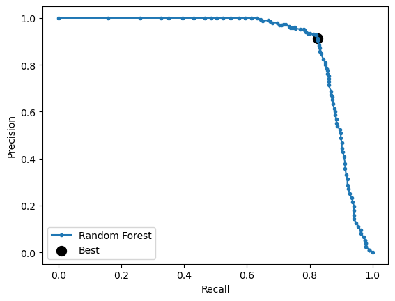

```python
# Plotting Precision-recall relation to maximize F2 Score:
plot_precision_recall_curve(ytest, y_pred_random_forest_prob, 'Random Forest')
```

```python
# Set the proba threshold to get the predictions:
threshold = 0.57
y_pred_random_forest = (y_pred_random_forest_prob[:,1] >= threshold).astype('int')
```

#### Metrics

```python
# Metrics display:
show_metrics(ytest, y_pred_random_forest, y_pred_random_forest_prob, 'Random Forest')
print("\nClassification Report\n")
print(classification_report(ytest, y_pred_random_forest))
```

```
Random Forest metrics:
Accuracy:  0.9997
Precision:  0.8902
Recall:  0.8217
F2:  0.8345
AUC:  0.993436161177838

Classification Report

              precision    recall  f1-score   support

           0       1.00      1.00      1.00    261858
           1       0.89      0.82      0.85       286

    accuracy                           1.00    262144
   macro avg       0.94      0.91      0.93    262144
weighted avg       1.00      1.00      1.00    262144
```

```python
# Train metrics display:
y_pred_random_forest_prob_train = clf_random_forest.predict_proba(xtrain_processed2)
y_pred_random_forest_train = (y_pred_random_forest_prob_train[:,1] >= threshold).astype('int')
show_metrics(ytrain_processed, y_pred_random_forest_train, y_pred_random_forest_prob_train, 'Random Forest')
```

```
Random Forest metrics:
Accuracy:  1.0
Precision:  1.0
Recall:  1.0
F2:  1.0
AUC:  1.0
```

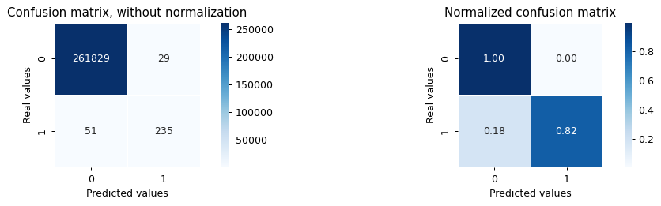

```python
# Confusion matrix display:
confusion_matrix_plot(ytest, y_pred_random_forest)
```

As expected, the random forest is able to classify the frauds better and therefore obtains better recall and f2 score.

#### Pickle

```python
# Saving the model:
joblib.dump(clf_random_forest, 'random_forest.pkl')
```

```
['random_forest.pkl']
```

### 6.3 SVC

```python
# Setting the model and Fitting the model:
clf_svc=SGDClassifier(random_state=0,loss="hinge").fit(xtrain_processed2, ytrain_processed)
calibrator=CalibratedClassifierCV(clf_svc,cv='prefit').fit(xtrain_processed2, ytrain_processed)
```

#### Predict

```python
# Calculating the probs for each class:
y_pred_svc_prob = calibrator.predict_proba(xtest_processed)
```

```
Best Threshold=0.639093, F2-Score=0.255
```

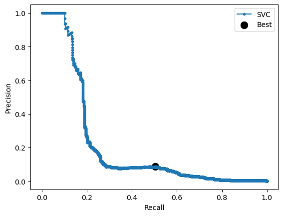

```python
# Plotting Precision-recall relation to maximize F2 Score:
plot_precision_recall_curve(ytest, y_pred_svc_prob, 'SVC')
```

```python
# Set the proba threshold to get the predictions:
threshold = 0.64
y_pred_svc = (y_pred_svc_prob[:,1] >= threshold).astype('int')
```

#### Metrics

```python
# Metrics display:
show_metrics(ytest, y_pred_svc, y_pred_svc_prob, 'SVC')
print("Classification Report")
print(classification_report(ytest, y_pred_svc))
```

```
SVC metrics:
Accuracy:  0.9936
Precision:  0.0846
Recall:  0.4965
F2:  0.2516
AUC:  0.9370132517773606
Classification Report
              precision    recall  f1-score   support

           0       1.00      0.99      1.00    261858
           1       0.08      0.50      0.14       286

    accuracy                           0.99    262144
   macro avg       0.54      0.75      0.57    262144
weighted avg       1.00      0.99      1.00    262144
```

```python
# Train metrics display:
y_pred_svc_prob_train= calibrator.predict_proba(xtrain_processed2)
y_pred_svc_train = (y_pred_svc_prob_train[:,1] >= threshold).astype('int')
show_metrics(ytrain_processed, y_pred_svc_train, y_pred_svc_prob_train, 'SVC')
```

```
SVC metrics:
Accuracy:  0.945
Precision:  0.8819
Recall:  0.456
F2:  0.5048
AUC:  0.9423352274393704
```

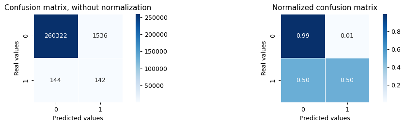

```python
# Confusion matrix display:
confusion_matrix_plot(ytest, y_pred_svc)
```

The SVC does not manage to classify frauds well, you can see in the confusion matrix that many of them are labeled as non-fraud. That is why the recall and f2 score metrics are so low.

#### Pickle

```python
# Save the model as a pickle in a file
joblib.dump(calibrator, 'SVC_CV_fit.pkl')
```

```
['SVC_CV_fit.pkl']
```

### 6.4 XGBOOST

```python
# Setting the model and Fitting the model:
clf_xgboost=XGBClassifier()
```

#### Fitting the model

```python
#Fitting the model
clf_xgboost.fit(xtrain_processed2, ytrain_processed)
```

```
XGBClassifier(base_score=0.5, booster='gbtree', callbacks=None,
              colsample_bylevel=1, colsample_bynode=1, colsample_bytree=1,
              early_stopping_rounds=None, enable_categorical=False,
              eval_metric=None, feature_types=None, gamma=0, gpu_id=-1,
              grow_policy='depthwise', importance_type=None,
              interaction_constraints='', learning_rate=0.300000012,
              max_bin=256, max_cat_threshold=64, max_cat_to_onehot=4,
              max_delta_step=0, max_depth=6, max_leaves=0, min_child_weight=1,
              missing=nan, monotone_constraints='()', n_estimators=100,
              n_jobs=0, num_parallel_tree=1, predictor='auto', random_state=0, ...)
```

#### Predict

```python
# Calculating the probs for each class:
y_pred_xgboost_prob = clf_xgboost.predict_proba(xtest_processed)
```

```
Best Threshold=0.299743, F2-Score=0.870
```

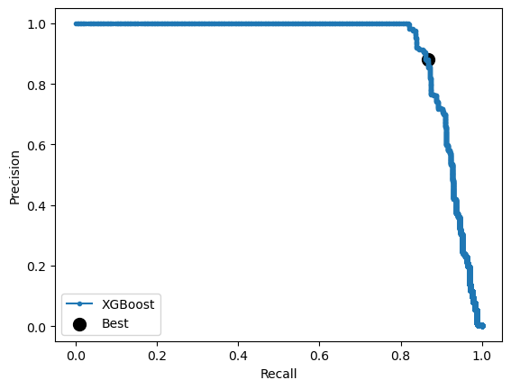

```python
# Plotting Precision-recall relation to maximize F2 Score:
plot_precision_recall_curve(ytest, y_pred_xgboost_prob, 'XGBoost')
```

```python
# Set the proba threshold to get the predictions:
threshold = 0.30
y_pred_xgboost = (y_pred_xgboost_prob[:,1] >= threshold).astype('int')
```

#### Metrics

```python
# Metrics display:
show_metrics(ytest, y_pred_xgboost, y_pred_xgboost_prob, 'XGBOOST')
print("Classification Report")
print(classification_report(ytest, y_pred_xgboost))
```

```
XGBOOST metrics:
Accuracy:  0.9997
Precision:  0.879
Recall:  0.8636
F2:  0.8667
AUC:  0.9962038358803017
Classification Report
              precision    recall  f1-score   support

           0       1.00      1.00      1.00    261858
           1       0.88      0.86      0.87       286

    accuracy                           1.00    262144
   macro avg       0.94      0.93      0.94    262144
weighted avg       1.00      1.00      1.00    262144
```

```python
# Train metrics display:
y_pred_xgboost_prob_train = clf_xgboost.predict_proba(xtrain_processed2)
y_pred_xgboost_train = (y_pred_xgboost_prob_train[:,1] >= threshold).astype('int')
show_metrics(ytrain_processed, y_pred_xgboost_train, y_pred_xgboost_prob_train, 'XGBOOST')
```

```
XGBOOST metrics:
Accuracy:  0.9999
Precision:  0.9996
Recall:  0.9996
F2:  0.9996
AUC:  0.999999179160307
```

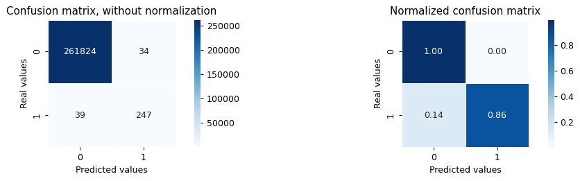

```python
# Confusion matrix display:
confusion_matrix_plot(ytest, y_pred_xgboost)
```

So far it is the best of the models, it manages to improve recall and f2 score metrics while maintaining a high precision.

#### Pickle

```python
# Save the model as a pickle in a file
joblib.dump(clf_xgboost, 'XGBOOST.pkl')
```

```
['XGBOOST.pkl']
```

### 6.5 Regresión logística (LASSO)

```python
# Setting the model and Fitting the model:
clf_log = LogisticRegression(penalty='l1', solver='liblinear')
```

#### Fitting the model

```python
# Fitting the model
clf_log.fit(xtrain_processed2, ytrain_processed)
```

```
LogisticRegression(penalty='l1', solver='liblinear')
```

#### Predict

```python
# Calculating the probs for each class:
y_pred_log_prob = clf_log.predict_proba(xtest_processed)
```

```
Best Threshold=0.879382, F2-Score=0.549
```

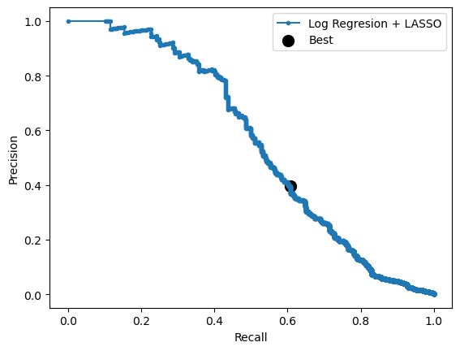

```python
# Plotting Precision-recall relation to maximize F2 Score:
plot_precision_recall_curve(ytest, y_pred_log_prob, 'Log Regresion + LASSO')
```

```python
# Set the proba threshold to get the predictions:
threshold = 0.88
y_pred_log = (y_pred_log_prob[:,1] >= threshold).astype('int')
```

#### Metrics

```python
# Metrics display:
show_metrics(ytest, y_pred_log, y_pred_log_prob, 'LOGISTIC REGRESION + LASSO')
print("Classification Report")
print(classification_report(ytest, y_pred_log))
```

```
LOGISTIC REGRESION + LASSO metrics:
Accuracy:  0.9986
Precision:  0.3941
Recall:  0.6049
F2:  0.5464
AUC:  0.990778819588709
Classification Report
              precision    recall  f1-score   support

           0       1.00      1.00      1.00    261858
           1       0.39      0.60      0.48       286

    accuracy                           1.00    262144
   macro avg       0.70      0.80      0.74    262144
weighted avg       1.00      1.00      1.00    262144
```

```python
# Train metrics display:
y_pred_log_prob_train = clf_log.predict_proba(xtrain_processed2)
y_pred_log_train = (y_pred_log_prob_train[:,1] >= threshold).astype('int')
show_metrics(ytrain_processed, y_pred_log_train, y_pred_log_prob_train, 'LOGISTIC REGRESION + LASSO')
```

```
LOGISTIC REGRESION + LASSO metrics:
Accuracy:  0.9689
Precision:  0.9861
Recall:  0.6675
F2:  0.7136
AUC:  0.9899522501228177
```

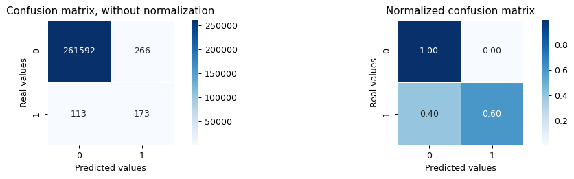

```python
# Confusion matrix display:
confusion_matrix_plot(ytest, y_pred_log)
```

Although it has better scores than the SVC, it performs significantly worse compared to the random forest and xgboost models.

#### Pickle

```python
# Save the model as a pickle in a file
joblib.dump(clf_log, 'LogisticRegressionLasso.pkl')
```

```
['LogisticRegressionLasso.pkl']
```

### 6.6 LIGHT GBM

```python
# Setting the model the model:
clf_lgbm = lgb.LGBMClassifier()
```

#### Fitting the model

```python
# Fitting the model
clf_lgbm_fit=clf_lgbm.fit(xtrain_processed2, ytrain_processed)
```

#### Predict

```python
# Calculating the probs for each class:
y_pred_lgbm_prob = clf_lgbm.predict_proba(xtest_processed)
```

```
Best Threshold=0.417541, F2-Score=0.845
```

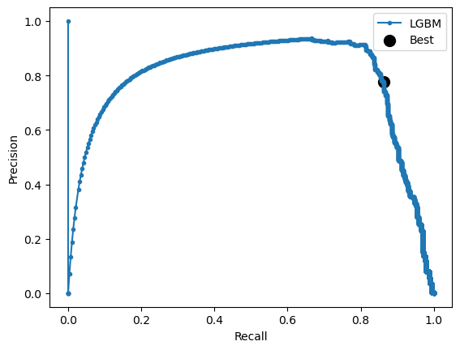

```python
# Plotting Precision-recall relation to maximize F2 Score:
plot_precision_recall_curve(ytest, y_pred_lgbm_prob, 'LGBM')
```

```python
# Set the proba threshold to get the predictions:
threshold = 0.42
y_pred_lgbm = (y_pred_lgbm_prob[:,1] >= threshold).astype('int')
```

#### Metrics

```python
# Metrics display:
show_metrics(ytest, y_pred_lgbm, y_pred_lgbm_prob, 'LIGHTGBM')
print("Classification Report")
print(classification_report(ytest, y_pred_lgbm))
```

```
LIGHTGBM metrics:
Accuracy:  0.9996
Precision:  0.7785
Recall:  0.8601
F2:  0.8425
AUC:  0.9965801742117532
Classification Report
              precision    recall  f1-score   support

           0       1.00      1.00      1.00    261858
           1       0.78      0.86      0.82       286

    accuracy                           1.00    262144
   macro avg       0.89      0.93      0.91    262144
weighted avg       1.00      1.00      1.00    262144
```

```python
# Train metrics display:
y_pred_lgbm_prob_train = clf_lgbm.predict_proba(xtrain_processed2)
y_pred_lgbm_train = (y_pred_lgbm_prob_train[:,1] >= threshold).astype('int')
show_metrics(ytrain_processed, y_pred_lgbm_train, y_pred_lgbm_prob_train, 'LIGHTGBM')
```

```
LIGHTGBM metrics:
Accuracy:  0.9996
Precision:  0.9983
Recall:  0.9969
F2:  0.9972
AUC:  0.9998752397233895
```

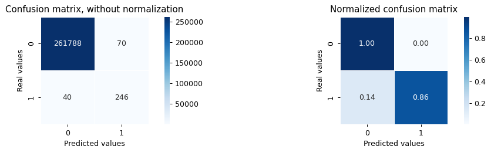

```python
# Confusion matrix display:
confusion_matrix_plot(ytest, y_pred_lgbm )
```

This model has good recall and f2 score, however, the precision is not so good.

#### Pickle

```python
# Save the model as a pickle in a file
joblib.dump(clf_lgbm, 'LIGHTGBM.pkl')
```

```
['LIGHTGBM.pkl']
```